# ATRAPP transcriptomics

October 11, 2018

# SAMSA2:standalone metatranscriptome analysis pipeline

• [samsa2 repo](https://github.com/transcript/samsa2)  
• [samsa2](https://www.ncbi.nlm.nih.gov/pmc/articles/PMC5963165/)

[figure not shown]

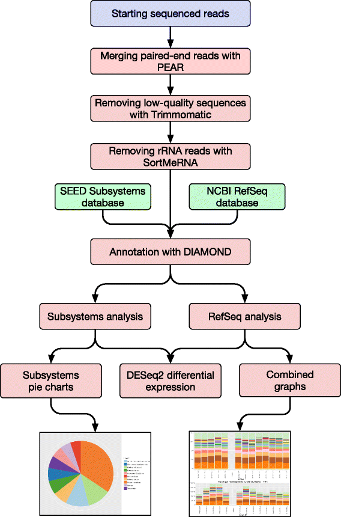

## RefSeq

• Species + protein name • 27G, 68M sequences

## Subseed

• SEED Subsystems: hierarchical functional activity (4 levels) • 7.6G, 2.9M sequences

# Data

• Lake Champlain metatranscriptomes (2 X 100bp Illumina HiSeq) • 3 sampling site: PRM (15 samples), St1 (27 samples), St2 (23 samples) • 130 fastq samples (79G of fastq.gz data)

# Running the pipeline

• Compute Canada Cedar • 48 CPUs, ~15hr X 3 sampling sites • I ran the pipeline seperately for each sampling site

## Examining the output

### Merging

```r
pe_assembly = read.table("results/summary_stats/pe_assembly",stringsAsFactors = F)
pe_assembly[,7] = sub("%","",pe_assembly[,7],fixed=T)
pe_assembly[,7] = sub("(","",pe_assembly[,7],fixed=T)
pe_assembly[,7] = sub(")","",pe_assembly[,7],fixed=T)
hist(as.numeric(pe_assembly[,7]),xlab = "% merged",main= "merging PE")
mean(as.numeric(pe_assembly[,7]))
```

[output not shown]

### Trimmomatic

```r
trimmed = read.table("results/summary_stats/trimmed",stringsAsFactors = F)
trimmed[,9] = sub("%","",trimmed[,9],fixed=T)
trimmed[,9] = sub("(","",trimmed[,9],fixed=T)
trimmed[,9] = sub(")","",trimmed[,9],fixed=T)
hist(as.numeric(trimmed[,9]),xlab = "% trimmed",main= "Trimmomatic")
mean(as.numeric(trimmed[,9]))
```

[output not shown]

### Ribosomes

```r
ribosomes = read.table("results/summary_stats/ribosomes",stringsAsFactors = F)
ribosomes[,9] = sub("%","",ribosomes[,9],fixed=T)
ribosomes[,9] = sub("(","",ribosomes[,9],fixed=T)
ribosomes[,9] = sub(")","",ribosomes[,9],fixed=T)
hist(as.numeric(ribosomes[,9]),xlab = "% ribosomes",main = "Ribosomes")
mean(as.numeric(ribosomes[,9]))
```

[output not shown]

### Annotations

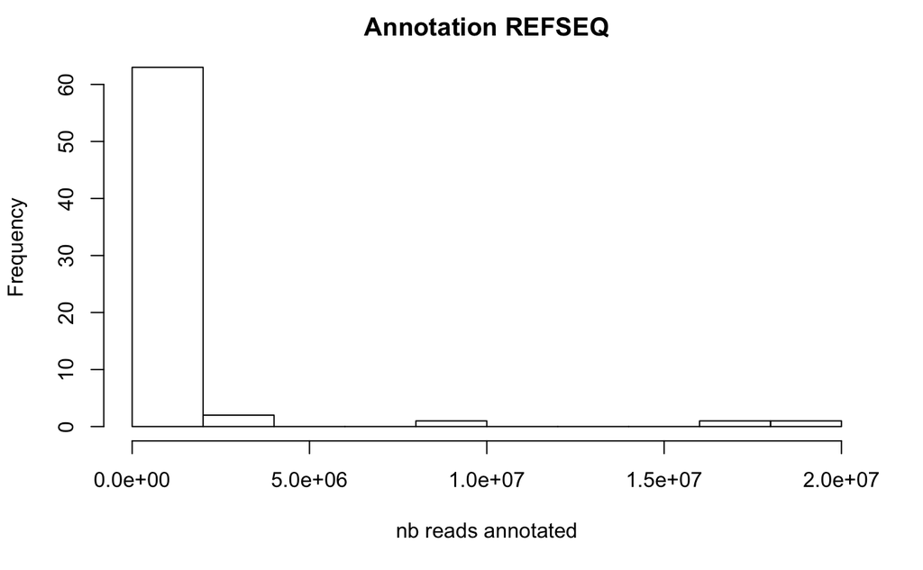

```r
refseq = read.table("results/summary_stats/refseq",stringsAsFactors = F)
subsys = read.table("results/summary_stats/subsys",stringsAsFactors = F)
hist(refseq[,1],xlab="nb reads annotated",main = "Annotation REFSEQ")
```

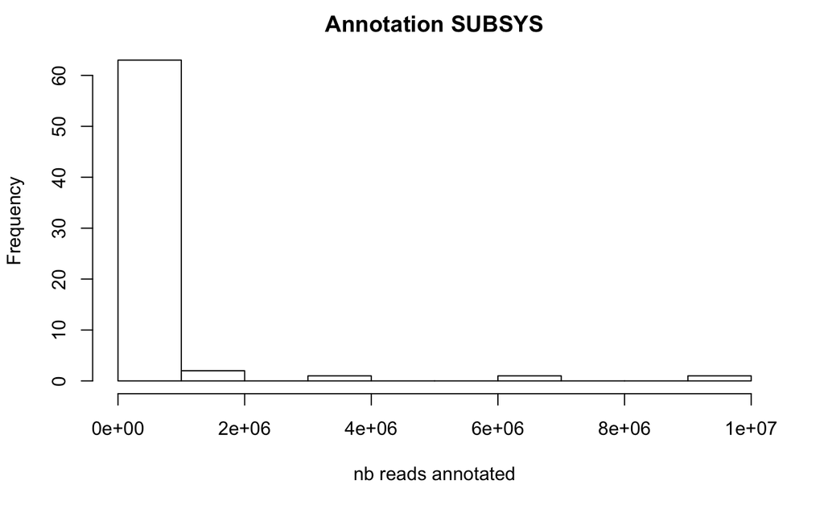

```r
hist(subsys[,1],xlab="nb reads annotated",main = "Annotation SUBSYS")
```

```r
#Total Number of sequences (~20k sequences / megabyte of fastq.gz)
nb_seq = 79*1000*20000
#What fraction of sequences are annotated (remember that here a merged sequence is composed of the 2 PEs)
#refseq
signif(sum(refseq[,1])/(nb_seq/2)*100,4)
```

```
[1] 11.51
```

```r
#subsys
signif(sum(subseq[,1])/(nb_seq/2)*100,4)
```

[output not shown]

```
Error: object 'subseq' not found
```

## Barplot

```r
#running the barplot graph
system("./Rcode/barplots.R")
knitr::include_graphics("figures/Champlain_barplot.pdf")
```

[output not shown]

### *I. massiliense*

• **ALL** *Inediibacterium massiliense* 20160915_St1 sequences match to a single hypothetical (*i.e predicted*) protein. • *e-values* ~e-20 (because sequences are small + %identity ~90%)

#### *I. massiliense* genome BLAST

• Download *I. massiliense* genome. • BLAST all sequences. • Sequences BLAST to a single region of ~150bp.